# 05/31 update

Molly Jenkins

May 31, 2017

## MODIS vs GIMMS NDVI data

I used the Weecology lab’s scripts for “get_ndvi_data” and “forecast_bbs_core” to extract the GIMMS data for BBS routes. I saved the raw extracted data to the core-transient data folder, and the post-2000 May-Aug subset to my scale_analysis folder.

The GIMMS BBS data (2000-2013) only generated 429 unique combinations of stateroute and NDVI values. The MODIS data (2000-2010) by comparison has vales for all 1003 unique combinations of stateroute and NDVI values.

```r
ndvi_modis = read.csv("scripts/R-scripts/scale_analysis/env_ndvi.csv", header = TRUE)
ndvi_gimms = read.csv("scripts/R-scripts/scale_analysis/ndvi_summer.csv", header = TRUE)
dim(ndvi_modis)
```

```
## [1] 1003    7
```

```r
dim(ndvi_gimms)
```

```
## [1] 429   3
```

Subsetting NDVI code below:

```r
#compare GIMMS to old MODIS based raster data
#may-aug, 2000-2014 (1005 rtes, vs 953 for 2001-2015)

#gimms
# ndvi_gimms_raw <- get_bbs_gimms_ndvi()
ndvi_gimms_raw = read.csv("data/BBS/ndvi_raw.csv", header = TRUE)

ndvi_data_summer <- ndvi_gimms_raw %>%
  filter(!is.na(ndvi), month %in% c('may', 'jun', 'jul', 'aug'), year > 2000) %>%
  group_by(site_id, year) %>% #calc avg across summer months for each year
  summarise(ndvi_sum = mean(ndvi), na.rm = TRUE) %>%
  group_by(site_id) %>% #calc avg across years
  summarise(ndvi_mean = mean(ndvi_sum), na.rm = TRUE) %>%
  ungroup()

dim(ndvi_data_summer)
```

```
## [1] 429   3
```

## Comparing variance in NDVI (MODIS) to variance in elevation

### Quantiles vs z scores, calculating scores themselves:

```r
####Calc z-scores, quantiles pre-variance loop####
bbs_envs = read.csv("scripts/R-scripts/scale_analysis/bbs_envs.csv", header = TRUE)

#alt simplistic standardization using z scores
bbs_envs$ztemp = (bbs_envs$temp.mean - mean(bbs_envs$temp.mean)) / sd(bbs_envs$temp.mean)
bbs_envs$zprec = (bbs_envs$prec.mean - mean(bbs_envs$prec.mean)) / sd(bbs_envs$prec.mean)
bbs_envs$zelev = (bbs_envs$elev.mean - mean(bbs_envs$elev.mean)) / sd(bbs_envs$elev.mean)
bbs_envs$zndvi = ((bbs_envs$ndvi.mean) - mean(na.exclude(bbs_envs$ndvi.mean))) / sd(na.exclude(bbs_envs$ndvi.mean))
#NA's for ndvi vals around statertes in the 3000's
#with z scores

# Calc quantiles
bbs_envs$ndvi_q= rank(bbs_envs$ndvi.mean)/nrow(bbs_envs) #needs to be corrected since NA values in ndvi col not being accounted for
bbs_envs$elev_q= rank(bbs_envs$elev.mean)/nrow(bbs_envs)
bbs_envs$temp_q= rank(bbs_envs$temp.mean)/nrow(bbs_envs)
bbs_envs$prec_q= rank(bbs_envs$prec.mean)/nrow(bbs_envs)
#write.csv(bbs_envs, "scripts/R-scripts/scale_analysis/bbs_envs.csv", row.names = FALSE)
#with z scores and quantiles both
```

### Calculating variance for both quantiles and z scores:

```r
bbs_envs = read.csv("scripts/R-scripts/scale_analysis/bbs_envs.csv", header = TRUE) #all env variables; both raw quantiles and raw z
dist.df = read.csv("scripts/R-scripts/scale_analysis/dist_df.csv", header = TRUE)

#num of rows matches num of rows in dts.df, good
#now calc var for each focal rte (rte1)
focal_var = data.frame(stateroute = NULL, ndvi_v = NULL, elev_v = NULL, prec_v = NULL, temp_v = NULL)
focal_qv = data.frame(stateroute = NULL, ndvi_qv = NULL, elev_qv = NULL, prec_qv = NULL, temp_qv = NULL)
focal_rtes = unique(bbs_envs$stateroute)

for(r in focal_rtes){
  rte_group = dist.df %>%
    filter(rte1 == r) %>%
    top_n(66, desc(dist)) %>%
    select(rte2) %>% as.vector()

  tempenv = bbs_envs %>%
    filter(stateroute %in% rte_group$rte2)

  #variance of z scores
  temp = data.frame(stateroute = r,
                    ndvi_v = var(tempenv$zndvi),
                    elev_v = var(tempenv$zelev), #bc each of these values is calculated across the 2ndary rtes for each focal rte
                    prec_v = var(tempenv$zprec), #such that all 66 2ndary rtes will be summed into one variance value for each focal rte
                    temp_v = var(tempenv$ztemp))

  #variance of quantiles
  temp2 = data.frame(stateroute = r,
                     ndvi_qv = var(tempenv$ndvi_q),
                     elev_qv = var(tempenv$elev_q),
                     prec_qv = var(tempenv$prec_q),
                     temp_qv = var(tempenv$temp_q))

  focal_var = rbind(focal_var, temp) #var of z scores
  focal_qv = rbind(focal_qv, temp2)  #var of quantiles
}
```

### Plotting variance of quantiles and variance of z scores; elev vs ndvi

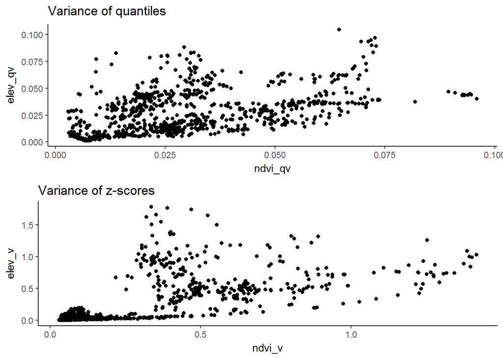

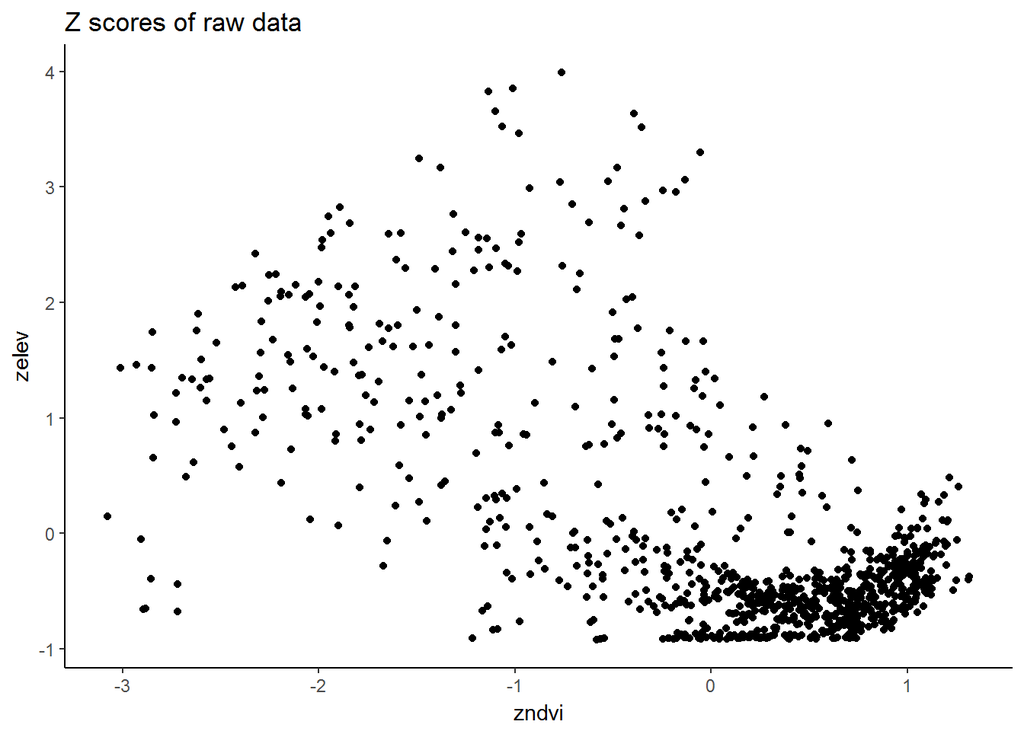

## Convex polygon hull

Not variances, just quantile values OR z scores for all four environmental variables - to boil them down to a single value. We went back and forth last time over which raw value tranformation would be more suitable, quantiles or z-scores, with no clear resolution.

So I get a value - what does this tell us? Should I recalculate this in a loop for each stateroute and compare them to each other? Such that the loop would calculate the convhulln for 4 environmental variables for a single row, and arrive at a single volume for each route And then I could analyze the variance in the volumes for each route?

```r
#notes on geometry package and min convex polygon:
#convhulln from geometry package, optimized by qhull -> convex hull
#http://www.qhull.org/html/qconvex.htm#synopsis
bbs_envs = read.csv("scripts/R-scripts/scale_analysis/bbs_envs.csv", header = TRUE)
#subset to just appropriate dims for convhulln
sub_envs = bbs_envs %>% select(temp_q, prec_q, elev_q, ndvi_q) %>% filter(ndvi_q != 'NA') #cuts down to 982


hull = convhulln(sub_envs, "FA")
hull$area #189.74
```

```
## [1] 3.584333
```

```r
hull$vol #66.22
```

```
## [1] 0.3909597
```